# Introduction

### Scientific Hypothesis: If Zaire Ebolavirus and Influenza type A's infectivities are explained by their different surface proteins, glycoprotein and hemagglutinin respectively, which they use to bind to cells, then we should expect to see very little similarity between their protein sequences.

# Loading in Packages

Seaborn: Seaborn is a data visualization library. It was based on the other package matplotlib. With it, user's are able to create detailed and colorful graphics. It is able to make various kinds of different graphics. With it I created a heatmap to display my analysis data. For more information on Seaborn, see https://seaborn.pydata.org/

Nglview is a package that is used to view molecular structures and trajectories. It allows the user to interact with a rendered 3D image of a molecule. One is able to completely rotate it in any direction and zoom in/out. With this I was able to render a 3D image of a modeled molecule for structural homology analysis. With this you can completely rotate it and zoom around. For more information of Nglview, see https://package.wiki/nglview

IPython: IPython is a command shell for interactive computing in python. It can be used for detailed object introspection. It also has various supplemental functions with it. For this I used it to load a png into my python. This is so that it was embedded in the html and so that it didn't show up in a pop up window when running the code. For more information on ipython, see https://pypi.org/project/ipython/

```python
# already installed
# conda install -c conda-forge biopython
```

```python
# already installed
# conda install -c anaconda seaborn
```

```python
# already installed
# conda install -c conda-forge nglview
```

```python
import Bio #
from Bio import SeqIO
from Bio.Seq import Seq
from Bio import pairwise2
import seaborn as sns #
from Bio.pairwise2 import format_alignment
import nglview as nv #
from Bio.PDB import*
from IPython import display #
```

# Performing Bioinformatics Analysis

The fasta files ("InfluenzaA_AAs.fasta", and "ZEBOV_AAs.fasta") uploaded contain the sequence of amino acids of the proteins being investigated. These were used for pairwise sequence alignment to find regions in the sequences that aligned with each other

For structural homology modeling, I used Swissmodel to create a model that showed the highest area of similarity between the 2 proteins. I input the amino acid sequences of the proteins for this and it created a pdb file that I input below.

Pairwise Sequence Alignment between the Zaire Ebolavirus and Influenza Type A hemagglutinin

```python
InfluenzaA = SeqIO.read("InfluenzaA_AAs.fasta", "fasta") #reads in the fasta
print(InfluenzaA) #prints fasta
InfluenzaA_seq = InfluenzaA.seq #gets the sequence
print(InfluenzaA_seq) #prints the sequence
```

```
ID: lcl|CR536510.1_cds_CAG38748.1_1
Name: lcl|CR536510.1_cds_CAG38748.1_1
Description: lcl|CR536510.1_cds_CAG38748.1_1 [gene=GSK3B] [db_xref=GOA:Q6FI27,HGNC:4617,InterPro:IPR000719,InterPro:IPR002290,InterPro:IPR008271,InterPro:IPR011009,InterPro:IPR017441,InterPro:IPR017442,UniProtKB/TrEMBL:Q6FI27] [protein_id=CAG38748.1] [location=1..1263] [gbkey=CDS]
Number of features: 0
Seq('MAIIYLILLFTAVRGDQICIGYHANNSTEKVDTNLERNVTVTHAKDILEKTHNG...ICI')
MAIIYLILLFTAVRGDQICIGYHANNSTEKVDTNLERNVTVTHAKDILEKTHNGKLCKLN…
```

```python
ZEBOV = SeqIO.read("ZEBOV_AAs.fasta", "fasta") #reads in the fasta
print(ZEBOV) #prints fasta
ZEBOV_seq = ZEBOV.seq #gets the sequence
print(ZEBOV_seq) #prints the sequence
```

```
ID: lcl|CR536510.1_cds_CAG38748.1_1
Name: lcl|CR536510.1_cds_CAG38748.1_1
Description: lcl|CR536510.1_cds_CAG38748.1_1 [gene=GSK3B] [db_xref=GOA:Q6FI27,HGNC:4617,InterPro:IPR000719,InterPro:IPR002290,InterPro:IPR008271,InterPro:IPR011009,InterPro:IPR017441,InterPro:IPR017442,UniProtKB/TrEMBL:Q6FI27] [protein_id=CAG38748.1] [location=1..1263] [gbkey=CDS]
Number of features: 0
Seq('MGVTGILQLPRDRFKRTSFFLWVIILFQRTFSIPLGVIHNSTLQVSDVDKLVCR...FVF')
MGVTGILQLPRDRFKRTSFFLWVIILFQRTFSIPLGVIHNSTLQVSDVDKLVCRDKLSST…
```

```python
alignment1 = pairwise2.align.globalxx(InfluenzaA_seq,ZEBOV_seq) #creates alignment between Influenza A Hemagglutinin and ZEBOV glycoprotein
print(format_alignment(*alignment1[0]))
```

```
MAIIYL----IL-L----F--TA-----VRGDQICI----------GY--HANNSTEKVDTNLERN-VT--VTHAKDILEKTHNGKL-C--KL---N-----GIPPLE-L-G-----DC--SIAG---WLLGNPECD-RLLS-VP------E---WS----YIM--E-KEN-PRDGL--CY-P----GS---FND----YEEL--K-------------H------L---LS-S-VKH------F-EK-VK----ILP--K-DRWTQHTTTGG--SRACAVSGN-PSFF-RNM--VWL--…
|         || |    |  |      |    | |          |   |  ||     | |    |   |    |        || |  ||   |     |   |  | |     |   | |    |  |      |  | ||      |   |     |    | |   | ||   |  |    |    |      |     |             |      |   |  | |        | |  |     |||  | |            |     |   |    |    |    …
M-----GVTGILQLPRDRFKRT-SFFLWV----I-ILFQRTFSIPLG-VIH--NS-----T-L---QV-SDV----D--------KLVCRDKLSSTNQLRSVG---L-NLEGNGVATD-VPS-A-TKRW--G-----FR--SGVPPKVVNYEAGEW-AENCY--NLEIK--KP-DG-SEC-LPAAPDG-IRGF--PRCRY---VHKVSGTGPCAGDFAFHKEGAFFLYDRL-ASTV--IYRGTTFAE-GV-VAFLILPQAKKD----------FFS-----S--HP---LR--EPV--NA…
  Score=231
```

```python
alignment2 = pairwise2.align.globalxx(InfluenzaA_seq,InfluenzaA_seq) #creates alignment between Influenza A Hemagglutinin with itself
print(format_alignment(*alignment2[0])) #prints this alignment
```

```
MAIIYLILLFTAVRGDQICIGYHANNSTEKVDTNLERNVTVTHAKDILEKTHNGKLCKLN…
||||||||||||||||||||||||||||||||||||||||||||||||||||||||||||||||||||||||||||||||||||||||||||||||||||||||||||||||||||||||||||||||||||||||||||||||||||||||||||||||||||||||||||||||||||||||||||||||||||||||||||||||||||||||||||||||||||||||||||||||||||||||||||||||||||||||||||||||||||||||||||||||||||||||||||…
MAIIYLILLFTAVRGDQICIGYHANNSTEKVDTNLERNVTVTHAKDILEKTHNGKLCKLN…
  Score=562
```

```python
alignment3 = pairwise2.align.globalxx(ZEBOV_seq,ZEBOV_seq) #creates alignment between ZEBOV glycoprotein with itself
print(format_alignment(*alignment3[0])) #prints this alignment
```

```
MGVTGILQLPRDRFKRTSFFLWVIILFQRTFSIPLGVIHNSTLQVSDVDKLVCRDKLSST…
||||||||||||||||||||||||||||||||||||||||||||||||||||||||||||||||||||||||||||||||||||||||||||||||||||||||||||||||||||||||||||||||||||||||||||||||||||||||||||||||||||||||||||||||||||||||||||||||||||||||||||||||||||||||||||||||||||||||||||||||||||||||||||||||||||||||||||||||||||||||||||||||||||||||||||…
MGVTGILQLPRDRFKRTSFFLWVIILFQRTFSIPLGVIHNSTLQVSDVDKLVCRDKLSST…
  Score=676
```

# Plotting the Results

```python
#I used 562 as the cap for the maximum similarity score so that the data would work in the heat map, as otherwise 562 and 676 which are both maximums, would show different values
array = [562, 231], [231, 562] #defines the datapoints I'm working with
```

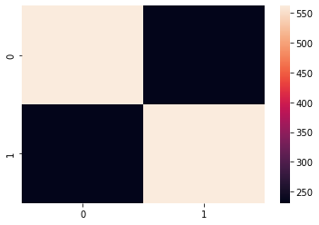

```python
heatmap = sns.heatmap(array) #creates heatmap of the previously defined array
```

This data shows that the similarities found from the pairwise sequence alignment between the ZEBOV glycoprotein and the Influenza type A hemagglutinin were very low compared to the similarities between those proteins with themselves (which will have the maximum similarity, of course)

Structural Homology Analysis between the Zaire Ebolavirus and Influenza Type A hemagglutinin

```python
parser = PDBParser() #defines parser as the PDBParser to be called later
Model1 = parser.get_structure("model_01", "model_01.pdb") #parses the pdb into Model1
view= nv.show_biopython(Model1) #defines view as the Model1 rendered image
view #calls Model1
```

[output not shown]

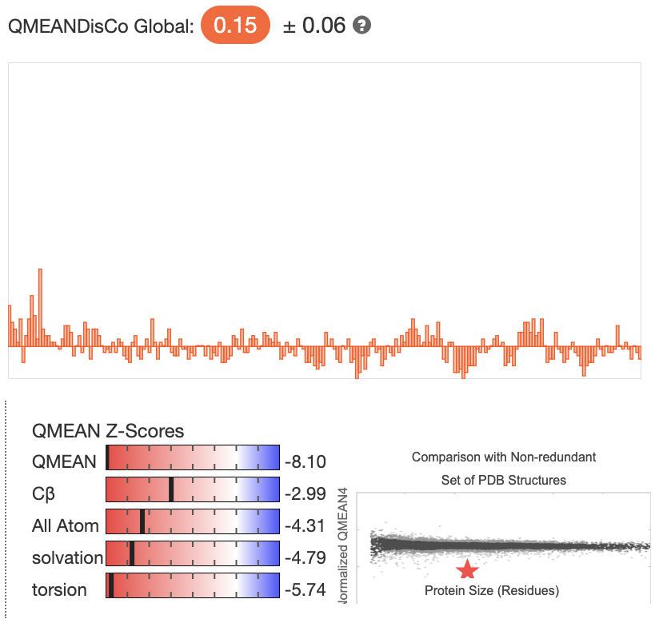

```python
display.Image('Quality Scores.png') #displays png
```

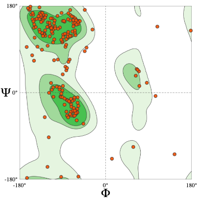

```python
display.Image('RamachandranPlot.png') #displays png
```

This data shows that there was very little overlap between the ZEBOV glycoprotein and the Influenza type A hemagglutinin regarding their structural homology.